# 6 months prediction

## Step 4 : Sample Dividing Procedure.

```r
model_select(y,t,1)
```

```
Call:
lm(formula = y ~ poly(x, poly.deg))

Residuals:
     Min       1Q   Median       3Q      Max
-0.46035 -0.03419  0.00279  0.03286  0.22130

Coefficients:
                  Estimate Std. Error t value Pr(>|t|)
(Intercept)       0.005251   0.003217   1.632    0.103
poly(x, poly.deg) 0.016304   0.062965   0.259    0.796

Residual standard error: 0.06297 on 381 degrees of freedom
Multiple R-squared:  0.000176,  Adjusted R-squared:  -0.002448
F-statistic: 0.06705 on 1 and 381 DF,  p-value: 0.7958
```

## Step 4 : The ACF analysis.

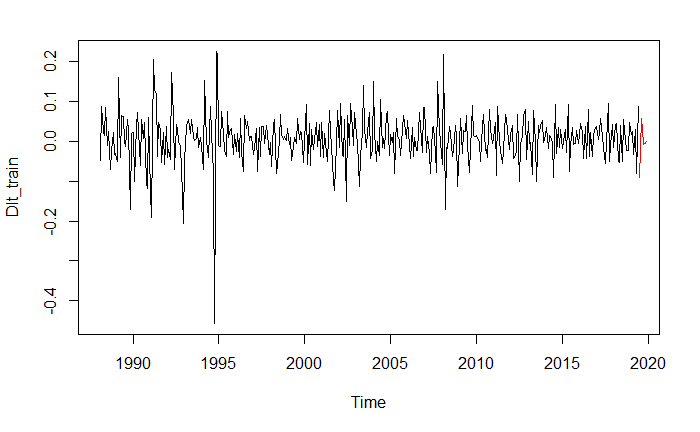

```r
Dlt_train <-  window(diff1_Deaseasoned_log_tourism, end = c(2019,06))
Dlt_test <- window(diff1_Deaseasoned_log_tourism, start= c(2019,07))
plot(Dlt_train)
lines(Dlt_test,col= "red")
```

```r
n <- length(Dlt_train)
max_lag <- floor(0.05*n)
max_lag
```

```
[1] 18
```

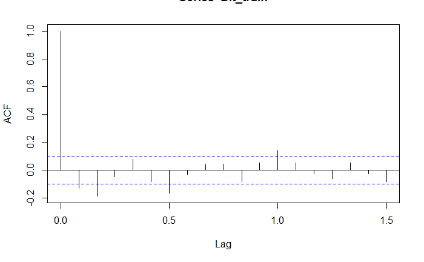

```r
acf(Dlt_train, lag.max = max_lag)
```

##### Ljung-Box test:

*Null Hypothesis:* $H_0$: at a given lag k, the acf coefficients $\rho_0= \rho_1= ... =\rho_k=0$. $H_1$: Coefficients != 0

*Note :* In statistical hypothesis testing, the **p-value** or probability value is the probability of obtaining test results at least as extreme as the results actually observed, assuming that the null hypothesis is correct. So here, the P-value of the test is the probability that a **chi-square test statistic** having the respective degrees of freedom is more extreme than the obtained test statistic.

*Interpret results:* If the P-value is less than the significance level (0.05), we reject the null hypothesis.

```r
rho <- acf(Dlt_train, lag.max = max_lag, plot = F)
length(rho$acf)
```

```
[1] 19
```

```r
k <- max_lag+1
Qt <- t(sapply(1:k,function(i) Box.test(Dlt_train, lag = i, type = "Ljung-Box")))
Qt <- as.data.frame(Qt)

result <- NULL

for(i in 1:k){
  if(Qt$p.value[[i]] < 0.05){
  result[i] <- "reject"

} else {result[i] <- "accept"}
}
result
```

```
 [1] "reject" "reject" "reject" "reject" "reject" "reject" "reject" "reject" "reject" "reject" "reject" "reject"
[13] "reject" "reject" "reject" "reject" "reject" "reject" "reject"
```

```r
acf_table <- data.frame(k= 1:k, sample_acf = rho$acf, p_values=as.numeric(Qt$p.value), test_statistic = as.numeric(Qt$statistic), result = as.vector(result))
head(acf_table)
```

|  | k | sample_acf | p_values | test_statistic | result |
| --- | --- | --- | --- | --- | --- |
| 1 | 1 | 1.00000000 | 1.107923e-02 | 6.452565 | reject |
| 2 | 2 | -0.13030763 | 5.453726e-05 | 19.633253 | reject |
| 3 | 3 | -0.18599205 | 1.344557e-04 | 20.488120 | reject |
| 4 | 4 | -0.04730367 | 1.363274e-04 | 22.839477 | reject |
| 5 | 5 | 0.07834719 | 1.138037e-04 | 25.454775 | reject |
| 6 | 6 | -0.08251668 | 3.010152e-06 | 35.803336 | reject |

```r
View(acf_table)
```

Here the *PACF* follows a standard normal distribution and we shall check the significance at 5% significance level which is 1.96. So we reject the Null hypothesis if the |test statistic| > 1.96 then we shall reject the null hypothesis.

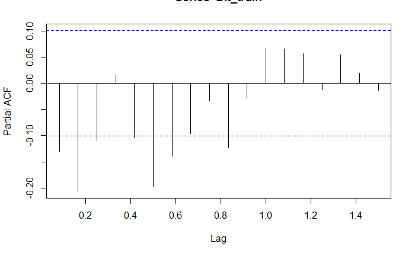

```r
pacf(Dlt_train, lag.max = max_lag)
```

```r
phi <- pacf(Dlt_train, lag.max = max_lag, plot = F)
length(phi$acf)
```

```
[1] 18
```

```r
Qt <- as.numeric(phi$acf*sqrt(n))
Qt <- abs(Qt)
result <- NULL

for(i in 1:max_lag){
  if(Qt[i] > 1.96){
  result[i] <- "reject"
  } else {result[i] <- "accept"}
}
result
```

```
 [1] "reject" "reject" "reject" "accept" "reject" "reject" "reject" "accept" "accept" "reject" "accept" "accept"
[13] "accept" "accept" "accept" "accept" "accept" "accept"
```

```r
pacf_table <- data.frame(k= 1:max_lag, sample_pacf = phi$acf,  test_statistic = Qt, result = as.vector(result))
head(pacf_table)
```

|  | k | sample_pacf | test_statistic | result |
| --- | --- | --- | --- | --- |
| 1 | 1 | -0.13030763 | 2.5301165 | reject |
| 2 | 2 | -0.20647815 | 4.0090804 | reject |
| 3 | 3 | -0.10992308 | 2.1343201 | reject |
| 4 | 4 | 0.01494557 | 0.2901904 | accept |
| 5 | 5 | -0.10432524 | 2.0256298 | reject |
| 6 | 6 | -0.19663783 | 3.8180161 | reject |

```r
View(pacf_table)
```

This auto selects the AR model, this shows that the AR model is AR(10)

```r
ar.burg(Dlt_train)
```

```
Call:
ar.burg.default(x = Dlt_train)

Coefficients:
      1        2        3        4        5       6       7       8       9      10
-0.2470 -0.2932 -0.2093 -0.1164 -0.2162 -0.2667 -0.1949 -0.1404 -0.0638 -0.1241

Order selected 10  sigma^2 estimated as  0.00335
```

```r
model <- arima(FTA_DL_train, order= c(10,1,0))
```

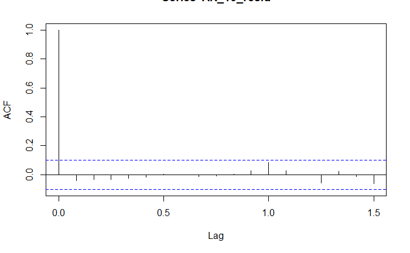

```r
AR_10_resid <- na.omit(model$residuals)
acf(AR_10_resid, lag.max = max_lag, plot = T)
```

```r
AR_10_resid
```

[output not shown]

[output cut: 51 more lines]

```r
parameter <- sum(eval((model$call$order)))
resid_acf <- acf(AR_10_resid, lag.max = 27, plot = F)
Rt <- t(sapply(1:28,function(i) Box.test(AR_10_resid, lag = i, type = "Ljung-Box", fitdf = parameter)))
```

[output not shown]

```r
Rt <- as.data.frame(Rt)
result <- NULL

for(i in (parameter+1):28)
  {
  if(Rt$p.value[[i]] < 0.01){
  result[i] <- "reject"

} else {result[i] <- "accept"}
}
residual_table <- cbind(K= 1:(28-parameter),na.omit(data.frame(
                            RESIDUAL_ACF = resid_acf$acf,
                             P_VALUES=as.numeric(Rt$p.value),
                             TEST_STATISTIC = as.numeric(Rt$statistic),
                             RESULT = as.vector(result)))
                            )
residual_table
```

|  | K | RESIDUAL_ACF | P_VALUES | TEST_STATISTIC | RESULT |
| --- | --- | --- | --- | --- | --- |
| 12 | 1 | 0.0275498764 | 0.02461355 | 5.050872 | accept |
| 13 | 2 | 0.0844972035 | 0.06939364 | 5.335920 | accept |
| 14 | 3 | 0.0269133549 | 0.14876667 | 5.336261 | accept |
| 15 | 4 | -0.0009300548 | 0.15820929 | 6.606388 | accept |
| 16 | 5 | -0.0566551181 | 0.23662648 | 6.791345 | accept |
| 17 | 6 | 0.0215899491 | 0.33446066 | 6.855048 | accept |
| 18 | 7 | -0.0126530912 | 0.30838025 | 8.282063 | accept |
| 19 | 8 | -0.0598036671 | 0.26957988 | 9.935533 | accept |
| 20 | 9 | -0.0642847020 | 0.19238389 | 12.386553 | accept |
| 21 | 10 | -0.0781586916 | 0.25005388 | 12.547976 | accept |

[output cut: 7 more lines]

```r
resid_acf <- acf(AR_10_resid, lag.max = 27, plot = F)
Rt <- t(sapply(1:28,function(i) Box.test(AR_10_resid, lag = i, type = "Ljung-Box", fitdf = parameter)))
```

[output not shown]

```r
Rt <- as.data.frame(Rt)

result <- NULL

for(i in (parameter+1):28){
  if(Rt$p.value[[i]] < 0.01){
  result[i] <- "reject"

} else {result[i] <- "accept"}
}
result
```

```
 [1] NA       NA       NA       NA       NA       NA       NA       NA       NA       NA       NA       "accept"
[13] "accept" "accept" "accept" "accept" "accept" "accept" "accept" "accept" "accept" "accept" "accept" "accept"
[25] "accept" "accept" "accept" "accept"
```

```r
residual_table <- data.frame(k= 1:28, sample_acf = resid_acf$acf, p_values=as.numeric(Rt$p.value), test_statistic = as.numeric(Rt$statistic), result = as.vector(result))
head(residual_table)
```

|  | k | sample_acf | p_values | test_statistic | result |
| --- | --- | --- | --- | --- | --- |
| 1 | 1 | 1.00000000 | NaN | 0.6765447 | NA |
| 2 | 2 | -0.04213871 | NaN | 1.1150495 | NA |
| 3 | 3 | -0.03388000 | NaN | 1.5178549 | NA |
| 4 | 4 | -0.03242840 | NaN | 1.7683767 | NA |
| 5 | 5 | -0.02554000 | NaN | 1.8571471 | NA |
| 6 | 6 | -0.01518276 | NaN | 1.8641492 | NA |

```r
View(residual_table)
```

This shows that 6 among the 10 coeffs of the model is significant.

```r
library(lmtest)
library(zoo)
coeftest(model)
```

```
z test of coefficients:

       Estimate Std. Error z value  Pr(>|z|)
ar1  -0.1991119  0.0514557 -3.8696  0.000109 ***
ar2  -0.2358472  0.0526100 -4.4829 7.362e-06 ***
ar3  -0.1457544  0.0539136 -2.7035  0.006862 **
ar4  -0.0513198  0.0539796 -0.9507  0.341744
ar5  -0.1589101  0.0530865 -2.9934  0.002759 **
ar6  -0.2089467  0.0529743 -3.9443 8.003e-05 ***
ar7  -0.1295999  0.0540252 -2.3989  0.016445 *
ar8  -0.0766136  0.0538937 -1.4216  0.155152
ar9  -0.0072288  0.0524920 -0.1377  0.890467
ar10 -0.0769891  0.0514667 -1.4959  0.134680
---
Signif. codes:  0 ‘***’ 0.001 ‘**’ 0.01 ‘*’ 0.05 ‘.’ 0.1 ‘ ’ 1
```

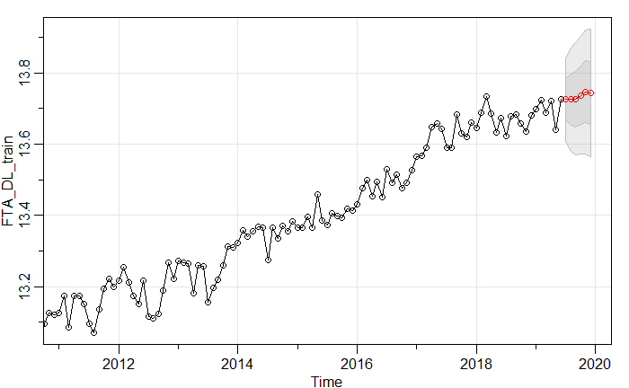

```r
Pred.arima <- sarima.for(FTA_DL_train, n.ahead = 6 , p = 10, d = 1, q= 0, P=0, D= 0, Q= 0, 12)
```

```r
PRED_ACTtable <- data.frame(Predict = Pred.arima$pred, FTA_DL_test)
colnames(PRED_ACTtable) <- c("Predict", "Actual")
PRED_ACTtable
```

| Predict | Actual |
| --- | --- |
| 13.72626 | 13.63647 |
| 13.72460 | 13.69337 |
| 13.72637 | 13.72370 |
| 13.73690 | 13.71668 |
| 13.74689 | 13.71047 |
| 13.74356 | 13.70939 |

```r
rmse_DL <- sqrt(mean((PRED_ACTtable$Predict- PRED_ACTtable$Actual)^2))
rmse_DL
```

```
[1] 0.04462361
```

```r
mape_DL <- mean(abs(PRED_ACTtable$Predict- PRED_ACTtable$Actual)/abs(PRED_ACTtable$Actual))*100
mape_DL
```

```
[1] 0.2613696
```

```r
Predict <- exp(PRED_ACTtable$Predict+S_index[7:12])
Predict
```

```
           Jul       Aug       Sep       Oct       Nov       Dec
2019  894251.1  823918.7  752514.4  963521.6 1132446.0 1268279.2
```

```r
Actual <- window(tourism, start= c(2019,07), end = c(2019,12))
Actual_predict_table <- data.frame(Predict = Predict, Actual = Actual)
Actual_predict_table
```

|  | Predict | Actual |
| --- | --- | --- |
| July | 894251.1 | 817455 |
| August | 823918.7 | 798587 |
| September | 752514.4 | 750514 |
| October | 963521.6 | 944233 |
| November | 1132446.0 | 1091946 |
| December | 1268279.2 | 1225672 |

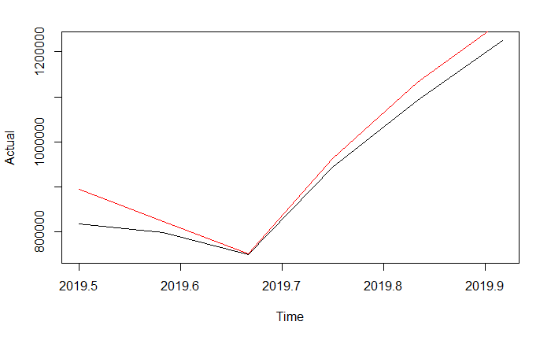

```r
plot(Actual)
lines(Predict, col = "red")
```